Load and view the information about the gapminder dataset on “dslabs”

```r
library("dslabs")
data(gapminder)
help(gapminder)
```

```
## starting httpd help server ... done
```

View the structure of the gapminder data set.

```r
str(gapminder)
```

```
## 'data.frame':    10545 obs. of  9 variables:
##  $ country         : Factor w/ 185 levels "Albania","Algeria",..: 1 2 3 4 5 6 7 8 9 10 ...
##  $ year            : int  1960 1960 1960 1960 1960 1960 1960 1960 1960 1960 ...
##  $ infant_mortality: num  115.4 148.2 208 NA 59.9 ...
##  $ life_expectancy : num  62.9 47.5 36 63 65.4 ...
##  $ fertility       : num  6.19 7.65 7.32 4.43 3.11 4.55 4.82 3.45 2.7 5.57 ...
##  $ population      : num  1636054 11124892 5270844 54681 20619075 ...
##  $ gdp             : num  NA 1.38e+10 NA NA 1.08e+11 ...
##  $ continent       : Factor w/ 5 levels "Africa","Americas",..: 4 1 1 2 2 3 2 5 4 3 ...
##  $ region          : Factor w/ 22 levels "Australia and New Zealand",..: 19 11 10 2 15 21 2 1 22 21 ...
```

View the summary of the gapminder dataset.

```r
summary(gapminder)
```

```
##                 country           year      infant_mortality
##  Albania            :   57   Min.   :1960   Min.   :  1.50
##  Algeria            :   57   1st Qu.:1974   1st Qu.: 16.00
##  Angola             :   57   Median :1988   Median : 41.50
##  Antigua and Barbuda:   57   Mean   :1988   Mean   : 55.31
##  Argentina          :   57   3rd Qu.:2002   3rd Qu.: 85.10
##  Armenia            :   57   Max.   :2016   Max.   :276.90
##  (Other)            :10203                  NA's   :1453
##  life_expectancy   fertility       population             gdp
##  Min.   :13.20   Min.   :0.840   Min.   :3.124e+04   Min.   :4.040e+07
##  1st Qu.:57.50   1st Qu.:2.200   1st Qu.:1.333e+06   1st Qu.:1.846e+09
##  Median :67.54   Median :3.750   Median :5.009e+06   Median :7.794e+09
##  Mean   :64.81   Mean   :4.084   Mean   :2.701e+07   Mean   :1.480e+11
##  3rd Qu.:73.00   3rd Qu.:6.000   3rd Qu.:1.523e+07   3rd Qu.:5.540e+10
##  Max.   :83.90   Max.   :9.220   Max.   :1.376e+09   Max.   :1.174e+13
##                  NA's   :187     NA's   :185         NA's   :2972
##     continent                region
##  Africa  :2907   Western Asia   :1026
##  Americas:2052   Eastern Africa : 912
##  Asia    :2679   Western Africa : 912
##  Europe  :2223   Caribbean      : 741
##  Oceania : 684   South America  : 684
##                  Southern Europe: 684
##                  (Other)        :5586
```

Check the class of the gapminder dataset to check what type of object the dataset is.

```r
class(gapminder)
```

```
## [1] "data.frame"
```

Create a subset of the data that contains only African countries. The subset function selects all rows that have the specified value. On the African country dataset, determine the structure (str) and the summary (summary) of the new object.

```r
africadata <- subset(gapminder, continent == "Africa")

str(africadata)
```

```
## 'data.frame':    2907 obs. of  9 variables:
##  $ country         : Factor w/ 185 levels "Albania","Algeria",..: 2 3 18 22 26 27 29 31 32 33 ...
##  $ year            : int  1960 1960 1960 1960 1960 1960 1960 1960 1960 1960 ...
##  $ infant_mortality: num  148 208 187 116 161 ...
##  $ life_expectancy : num  47.5 36 38.3 50.3 35.2 ...
##  $ fertility       : num  7.65 7.32 6.28 6.62 6.29 6.95 5.65 6.89 5.84 6.25 ...
##  $ population      : num  11124892 5270844 2431620 524029 4829291 ...
##  $ gdp             : num  1.38e+10 NA 6.22e+08 1.24e+08 5.97e+08 ...
##  $ continent       : Factor w/ 5 levels "Africa","Americas",..: 1 1 1 1 1 1 1 1 1 1 ...
##  $ region          : Factor w/ 22 levels "Australia and New Zealand",..: 11 10 20 17 20 5 10 20 10 10 ...
```

```r
summary(africadata)
```

```
##          country          year      infant_mortality life_expectancy
##  Algeria     :  57   Min.   :1960   Min.   : 11.40   Min.   :13.20
##  Angola      :  57   1st Qu.:1974   1st Qu.: 62.20   1st Qu.:48.23
##  Benin       :  57   Median :1988   Median : 93.40   Median :53.98
##  Botswana    :  57   Mean   :1988   Mean   : 95.12   Mean   :54.38
##  Burkina Faso:  57   3rd Qu.:2002   3rd Qu.:124.70   3rd Qu.:60.10
##  Burundi     :  57   Max.   :2016   Max.   :237.40   Max.   :77.60
##  (Other)     :2565                  NA's   :226
##    fertility       population             gdp               continent
##  Min.   :1.500   Min.   :    41538   Min.   :4.659e+07   Africa  :2907
##  1st Qu.:5.160   1st Qu.:  1605232   1st Qu.:8.373e+08   Americas:   0
##  Median :6.160   Median :  5570982   Median :2.448e+09   Asia    :   0
##  Mean   :5.851   Mean   : 12235961   Mean   :9.346e+09   Europe  :   0
##  3rd Qu.:6.860   3rd Qu.: 13888152   3rd Qu.:6.552e+09   Oceania :   0
##  Max.   :8.450   Max.   :182201962   Max.   :1.935e+11
##  NA's   :51      NA's   :51          NA's   :637
##                        region
##  Eastern Africa           :912
##  Western Africa           :912
##  Middle Africa            :456
##  Northern Africa          :342
##  Southern Africa          :285
##  Australia and New Zealand:  0
##  (Other)                  :  0
```

Create the babies object. From the africadata dataset extract the infant_mortality and the life_expectancy columns. Characterize the object’s structure and summary.

```r
babies <- subset(africadata, select = c(infant_mortality, life_expectancy))

str(babies)
```

```
## 'data.frame':    2907 obs. of  2 variables:
##  $ infant_mortality: num  148 208 187 116 161 ...
##  $ life_expectancy : num  47.5 36 38.3 50.3 35.2 ...
```

```r
summary(babies)
```

```
##  infant_mortality life_expectancy
##  Min.   : 11.40   Min.   :13.20
##  1st Qu.: 62.20   1st Qu.:48.23
##  Median : 93.40   Median :53.98
##  Mean   : 95.12   Mean   :54.38
##  3rd Qu.:124.70   3rd Qu.:60.10
##  Max.   :237.40   Max.   :77.60
##  NA's   :226
```

Create the persons object. From the africadata dataset extract the population and the life_expectancy columns. Characterize the object’s structure and summary.

```r
persons <- subset(africadata, select = c(population, life_expectancy))

str(persons)
```

```
## 'data.frame':    2907 obs. of  2 variables:
##  $ population     : num  11124892 5270844 2431620 524029 4829291 ...
##  $ life_expectancy: num  47.5 36 38.3 50.3 35.2 ...
```

```r
summary(persons)
```

```
##    population        life_expectancy
##  Min.   :    41538   Min.   :13.20
##  1st Qu.:  1605232   1st Qu.:48.23
##  Median :  5570982   Median :53.98
##  Mean   : 12235961   Mean   :54.38
##  3rd Qu.: 13888152   3rd Qu.:60.10
##  Max.   :182201962   Max.   :77.60
##  NA's   :51
```

Graph the infant data with life expectancy on the y-axis.

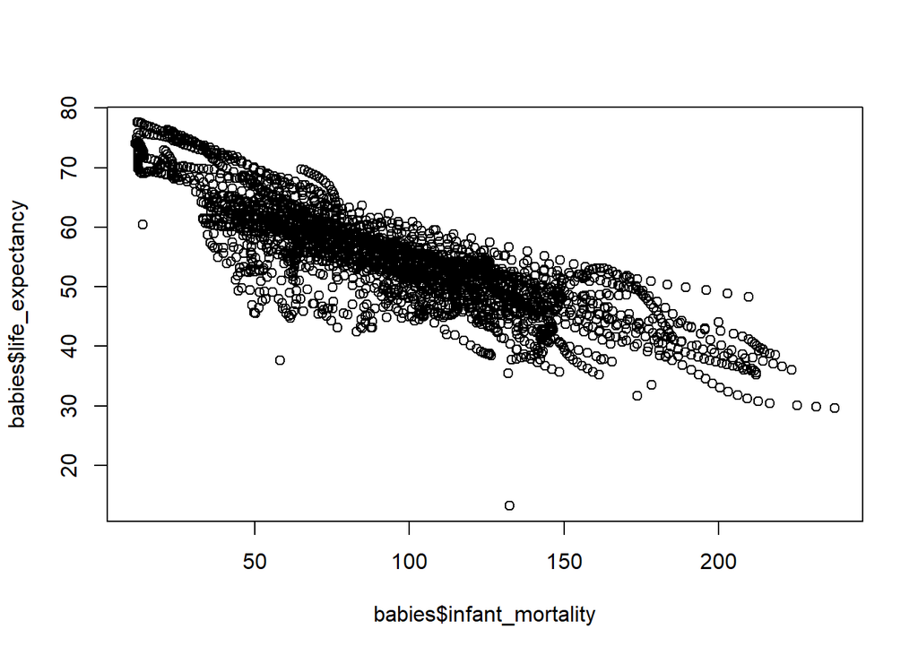

```r
plot(x = babies$infant_mortality, y = babies$life_expectancy, type = "p")
```

There is a negative correlation between infant mortality and life expectancy.

Graph the total population data with life expectancy on the y-axis

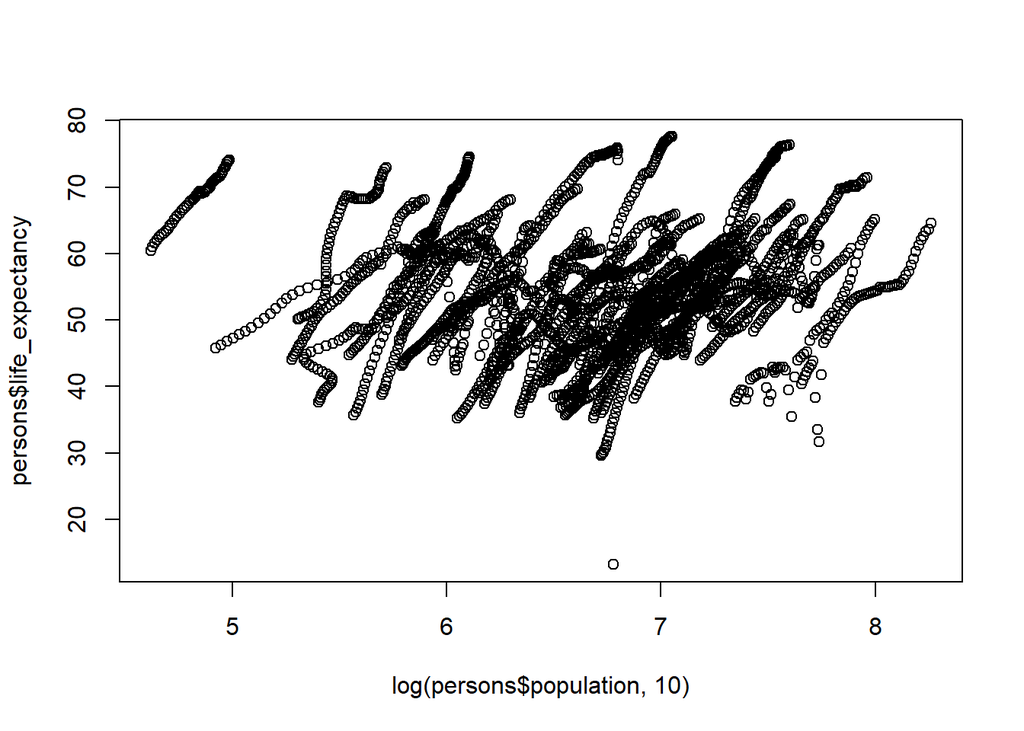

```r
plot(x = log(persons$population, 10), y = persons$life_expectancy)
```

There is a positive corelation between population and life expectancy. There are individual streaks of data because Africa is composed of many different countries, each of which with their own populations and life expectancy data. I hypothesize that the streaks correspond to specific countries.

We need to look at one year that has the most data for life expectancy, infant mortality and population size. So first lets figure out the years that are missing data for infant mortality.

I’m pretty sure that we need to use indexing for this. Of the africadata dataset I will index the NA values for the infant_mortality variable. Then I will apply those index values to the year variable and pull out which year corresponds to the NA values. Then, maybe at the end I’ll be able to count how many of each year I have to determine the year with the least amount of NA’s.

```r
ind <- is.na(africadata$infant_mortality)

missing_years <- africadata$year[ind]

print(missing_years)
```

```
##   [1] 1960 1960 1960 1960 1960 1960 1960 1960 1960 1960 1961 1961 1961 1961
##  [15] 1961 1961 1961 1961 1961 1961 1961 1961 1961 1961 1961 1961 1961 1962
##  [29] 1962 1962 1962 1962 1962 1962 1962 1962 1962 1962 1962 1962 1962 1962
##  [43] 1962 1963 1963 1963 1963 1963 1963 1963 1963 1963 1963 1963 1963 1963
##  [57] 1963 1963 1963 1964 1964 1964 1964 1964 1964 1964 1964 1964 1964 1964
##  [71] 1964 1964 1964 1964 1965 1965 1965 1965 1965 1965 1965 1965 1965 1965
##  [85] 1965 1965 1965 1965 1966 1966 1966 1966 1966 1966 1966 1966 1966 1966
##  [99] 1966 1966 1966 1967 1967 1967 1967 1967 1967 1967 1967 1967 1967 1967
## [113] 1968 1968 1968 1968 1968 1968 1968 1968 1968 1968 1968 1969 1969 1969
## [127] 1969 1969 1969 1969 1970 1970 1970 1970 1970 1971 1971 1971 1971 1971
## [141] 1971 1972 1972 1972 1972 1972 1972 1973 1973 1973 1973 1973 1973 1974
## [155] 1974 1974 1974 1974 1975 1975 1975 1975 1975 1976 1976 1976 1977 1977
## [169] 1977 1978 1978 1979 1979 1980 1981 2016 2016 2016 2016 2016 2016 2016
## [183] 2016 2016 2016 2016 2016 2016 2016 2016 2016 2016 2016 2016 2016 2016
## [197] 2016 2016 2016 2016 2016 2016 2016 2016 2016 2016 2016 2016 2016 2016
## [211] 2016 2016 2016 2016 2016 2016 2016 2016 2016 2016 2016 2016 2016 2016
## [225] 2016 2016
```

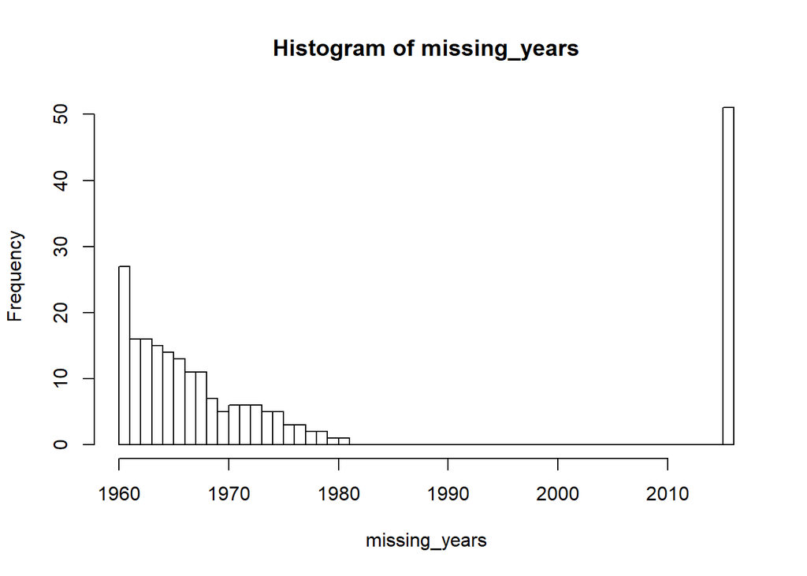

```r
hist(missing_years, breaks = 40, freq = TRUE)
```

Year 2000 does not have any NAs, so extract the data from the year 2000, and check the structure and summary for the data set.

```r
Year2000 <- subset(africadata, year == "2000")

str(Year2000)
```

```
## 'data.frame':    51 obs. of  9 variables:
##  $ country         : Factor w/ 185 levels "Albania","Algeria",..: 2 3 18 22 26 27 29 31 32 33 ...
##  $ year            : int  2000 2000 2000 2000 2000 2000 2000 2000 2000 2000 ...
##  $ infant_mortality: num  33.9 128.3 89.3 52.4 96.2 ...
##  $ life_expectancy : num  73.3 52.3 57.2 47.6 52.6 46.7 54.3 68.4 45.3 51.5 ...
##  $ fertility       : num  2.51 6.84 5.98 3.41 6.59 7.06 5.62 3.7 5.45 7.35 ...
##  $ population      : num  31183658 15058638 6949366 1736579 11607944 ...
##  $ gdp             : num  5.48e+10 9.13e+09 2.25e+09 5.63e+09 2.61e+09 ...
##  $ continent       : Factor w/ 5 levels "Africa","Americas",..: 1 1 1 1 1 1 1 1 1 1 ...
##  $ region          : Factor w/ 22 levels "Australia and New Zealand",..: 11 10 20 17 20 5 10 20 10 10 ...
```

```r
summary(Year2000)
```

```
##          country        year      infant_mortality life_expectancy
##  Algeria     : 1   Min.   :2000   Min.   : 12.30   Min.   :37.60
##  Angola      : 1   1st Qu.:2000   1st Qu.: 60.80   1st Qu.:51.75
##  Benin       : 1   Median :2000   Median : 80.30   Median :54.30
##  Botswana    : 1   Mean   :2000   Mean   : 78.93   Mean   :56.36
##  Burkina Faso: 1   3rd Qu.:2000   3rd Qu.:103.30   3rd Qu.:60.00
##  Burundi     : 1   Max.   :2000   Max.   :143.30   Max.   :75.00
##  (Other)     :45
##    fertility       population             gdp               continent
##  Min.   :1.990   Min.   :    81154   Min.   :2.019e+08   Africa  :51
##  1st Qu.:4.150   1st Qu.:  2304687   1st Qu.:1.274e+09   Americas: 0
##  Median :5.550   Median :  8799165   Median :3.238e+09   Asia    : 0
##  Mean   :5.156   Mean   : 15659800   Mean   :1.155e+10   Europe  : 0
##  3rd Qu.:5.960   3rd Qu.: 17391242   3rd Qu.:8.654e+09   Oceania : 0
##  Max.   :7.730   Max.   :122876723   Max.   :1.329e+11
##
##                        region
##  Eastern Africa           :16
##  Western Africa           :16
##  Middle Africa            : 8
##  Northern Africa          : 6
##  Southern Africa          : 5
##  Australia and New Zealand: 0
##  (Other)                  : 0
```

Now create the two plots again. Look at life expectancy vs infant mortality and life expectancy vs population.

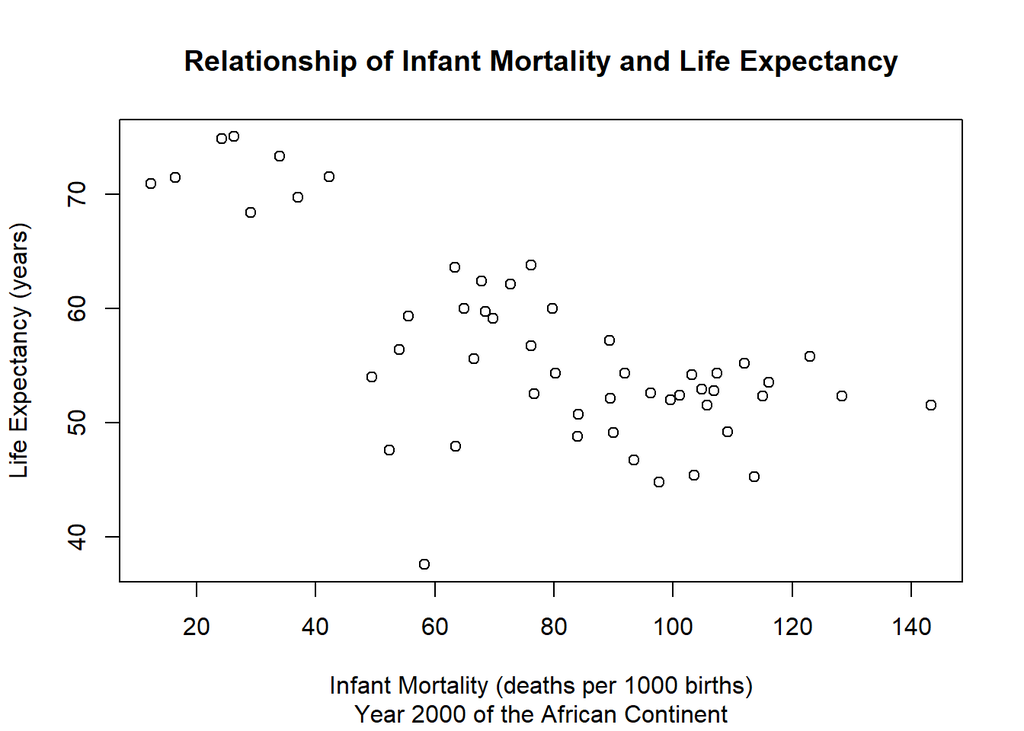

```r
plot(x = Year2000$infant_mortality, y = Year2000$life_expectancy, main = "Relationship of Infant Mortality and Life Expectancy", sub = "Year 2000 of the African Continent", xlab = "Infant Mortality (deaths per 1000 births)", ylab = "Life Expectancy (years)")
```

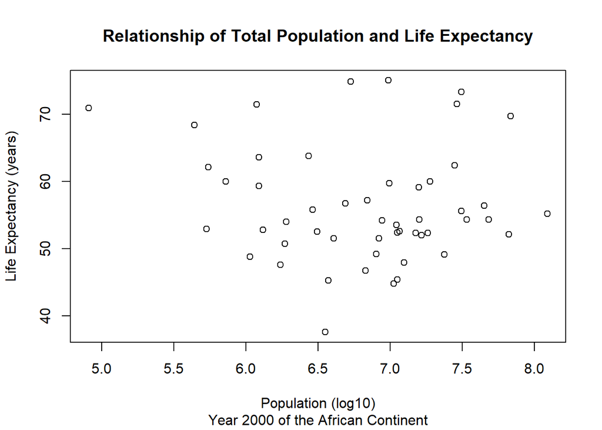

```r
plot(x = log(Year2000$population, 10), y = Year2000$life_expectancy, main = "Relationship of Total Population and Life Expectancy", sub = "Year 2000 of the African Continent", xlab = "Population (log10)", ylab = "Life Expectancy (years)")
```

There seems to be a negative relationship between infant mortality and life expectancy. There is no distinguishable relationship between the overall population and life expectancy. So we’re going to look a little more into infant mortality.

Fit the data (infant mortality = fit1; population size = fit2) to a linear fit with the lm function. To use the lm function the first argument is a formula. For simple linear regression the formula is “Yvariable ~ Xvariable”, where Yvariable is the dependent, or predicted, variable and Xvariable is the independent, or predictor, variable.

```r
fit1 <- lm(Year2000$life_expectancy ~ Year2000$infant_mortality)

fit2 <- lm(Year2000$life_expectancy ~ log(Year2000$population, 10))

summary(fit1)
```

```
##
## Call:
## lm(formula = Year2000$life_expectancy ~ Year2000$infant_mortality)
##
## Residuals:
##      Min       1Q   Median       3Q      Max
## -22.6651  -3.7087   0.9914   4.0408   8.6817
##
## Coefficients:
##                           Estimate Std. Error t value Pr(>|t|)
## (Intercept)               71.29331    2.42611  29.386  < 2e-16 ***
## Year2000$infant_mortality -0.18916    0.02869  -6.594 2.83e-08 ***
## ---
## Signif. codes:  0 '***' 0.001 '**' 0.01 '*' 0.05 '.' 0.1 ' ' 1
##
## Residual standard error: 6.221 on 49 degrees of freedom
## Multiple R-squared:  0.4701, Adjusted R-squared:  0.4593
## F-statistic: 43.48 on 1 and 49 DF,  p-value: 2.826e-08
```

```r
summary(fit2)
```

```
##
## Call:
## lm(formula = Year2000$life_expectancy ~ log(Year2000$population,
##     10))
##
## Residuals:
##     Min      1Q  Median      3Q     Max
## -19.113  -4.809  -1.554   3.907  18.863
##
## Coefficients:
##                              Estimate Std. Error t value Pr(>|t|)
## (Intercept)                    65.324     12.520   5.217 3.65e-06 ***
## log(Year2000$population, 10)   -1.315      1.829  -0.719    0.476
## ---
## Signif. codes:  0 '***' 0.001 '**' 0.01 '*' 0.05 '.' 0.1 ' ' 1
##
## Residual standard error: 8.502 on 49 degrees of freedom
## Multiple R-squared:  0.01044,    Adjusted R-squared:  -0.009755
## F-statistic: 0.517 on 1 and 49 DF,  p-value: 0.4755
```

Infant mortality has a negative linear relationship with life expectancy (F = 43.48; d.f. = 49; p = 2.826e-08), and explains 45.93% (6.221 = standard error) of the variance in life expectancy.

```r
#Module 6 Tidyverse Exercise written by Jonathan Wilson

library(tidyverse)
library(skimr)
glimpse(gapminder)
```

```
## Observations: 10,545
## Variables: 9
## $ country          <fct> Albania, Algeria, Angola, Antigua and Barbuda...
## $ year             <int> 1960, 1960, 1960, 1960, 1960, 1960, 1960, 196...
## $ infant_mortality <dbl> 115.40, 148.20, 208.00, NA, 59.87, NA, NA, 20...
## $ life_expectancy  <dbl> 62.87, 47.50, 35.98, 62.97, 65.39, 66.86, 65....
## $ fertility        <dbl> 6.19, 7.65, 7.32, 4.43, 3.11, 4.55, 4.82, 3.4...
## $ population       <dbl> 1636054, 11124892, 5270844, 54681, 20619075, ...
## $ gdp              <dbl> NA, 13828152297, NA, NA, 108322326649, NA, NA...
## $ continent        <fct> Europe, Africa, Africa, Americas, Americas, A...
## $ region           <fct> Southern Europe, Northern Africa, Middle Afri...
```

```r
skim(gapminder)
```

```
## Skim summary statistics
##  n obs: 10545
##  n variables: 9
##
## -- Variable type:factor ------------------------------------------------------------
##   variable missing complete     n n_unique
##  continent       0    10545 10545        5
##    country       0    10545 10545      185
##     region       0    10545 10545       22
##                                  top_counts ordered
##  Afr: 2907, Asi: 2679, Eur: 2223, Ame: 2052   FALSE
##          Alb: 57, Alg: 57, Ang: 57, Ant: 57   FALSE
##     Wes: 1026, Eas: 912, Wes: 912, Car: 741   FALSE
##
## -- Variable type:integer -----------------------------------------------------------
##  variable missing complete     n mean    sd   p0  p25  p50  p75 p100
##      year       0    10545 10545 1988 16.45 1960 1974 1988 2002 2016
##      hist
##  ▇▇▇▇▇▇▇▇
##
## -- Variable type:numeric -----------------------------------------------------------
##          variable missing complete     n     mean          sd       p0
##         fertility     187    10358 10545  4.08        2.03        0.84
##               gdp    2972     7573 10545  1.5e+11 7e+11       4e+07
##  infant_mortality    1453     9092 10545 55.31       47.73        1.5
##   life_expectancy       0    10545 10545 64.81       10.67       13.2
##        population     185    10360 10545  2.7e+07     1.1e+08 31238
##            p25         p50      p75      p100     hist
##        2.2         3.75     6         9.22    ▅▇▃▃▅▆▂▁
##        1.8e+09     7.8e+09  5.5e+10   1.2e+13 ▇▁▁▁▁▁▁▁
##       16          41.5     85.1     276.9     ▇▃▂▂▁▁▁▁
##       57.5        67.54    73        83.9     ▁▁▁▂▃▅▇▃
##  1333486       5e+06        1.5e+07   1.4e+09 ▇▁▁▁▁▁▁▁
```

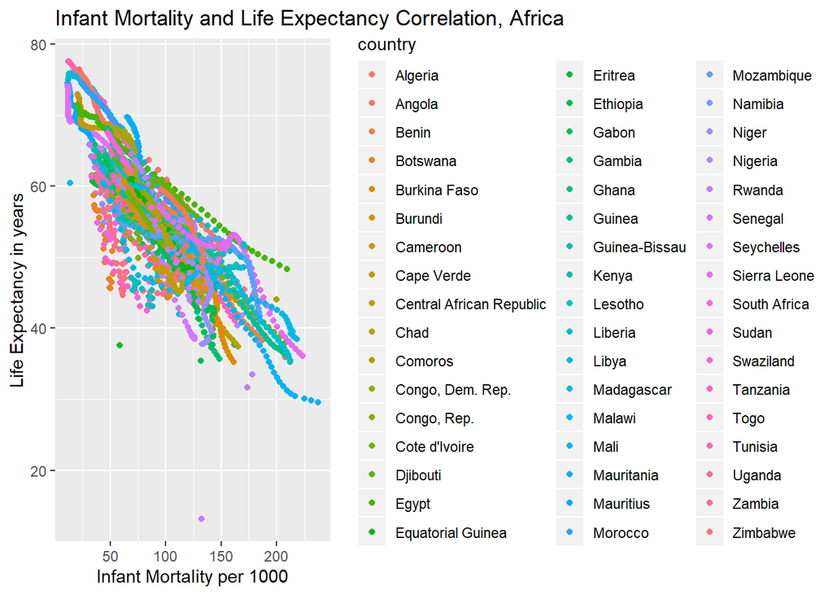

```r
#select African countries and extract data and keep variables infant_mortality, life_expectancy, population and country, using filter and select from dplyr

gapminder %>%

  filter(continent == "Africa") %>%

  select(infant_mortality, life_expectancy, population, country) %>%

#use ggplot to make 2 plots of life expectancy as a function of infant mortality and then of population, using a different colour for each country

  ggplot() + geom_point(aes(infant_mortality, life_expectancy, col= country)) + labs(x="Infant Mortality per 1000", y= "Life Expectancy in years", title= "Infant Mortality and Life Expectancy Correlation, Africa")
```

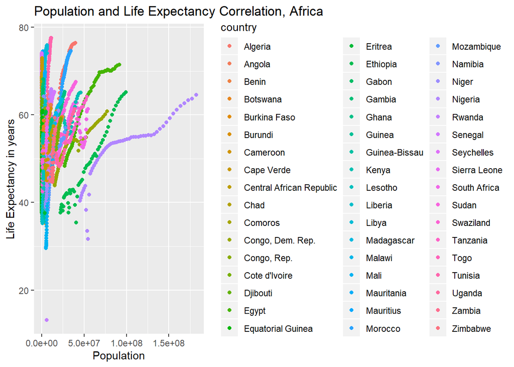

```r
#now repeat with population

gapminder %>%

  filter(continent == "Africa") %>%

  select(infant_mortality, life_expectancy, population, country) %>%

  ggplot() + geom_point(aes(population, life_expectancy, col= country)) + labs(x="Population", y= "Life Expectancy in years", title= "Population and Life Expectancy Correlation, Africa")
```

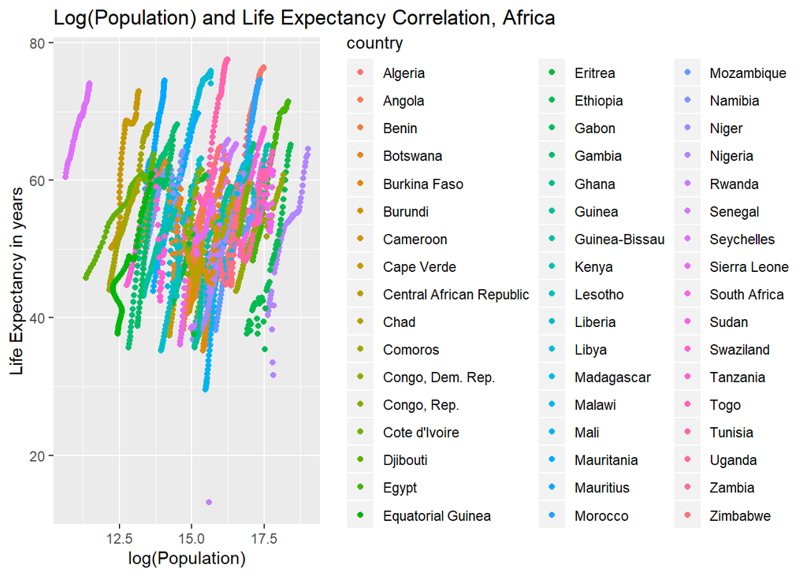

```r
#Repeated again with log(population)
gapminder %>%

  filter(continent == "Africa") %>%

  select(infant_mortality, life_expectancy, population, country) %>%

  ggplot() + geom_point(aes(log(population), life_expectancy, col= country)) +labs(x="log(Population)", y= "Life Expectancy in years", title= "Log(Population) and Life Expectancy Correlation, Africa")
```

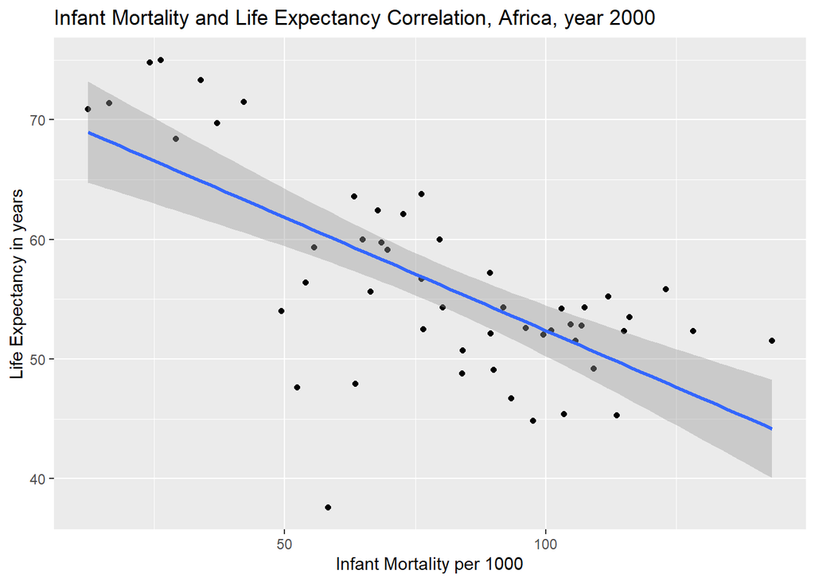

```r
#now make another plot using gapminder object
#this time pull only the data for the year 2000 and Africa and plot infant mortality vs life expectancy
#also add linear fit model to plot

gapminder %>%

  filter(continent == "Africa", year == 2000) %>%

  select(infant_mortality, life_expectancy, population, country) %>%

  ggplot(aes(infant_mortality, life_expectancy)) + geom_point() + geom_smooth(method = "lm") + labs(x="Infant Mortality per 1000", y= "Life Expectancy in years", title= "Infant Mortality and Life Expectancy Correlation, Africa, year 2000")
```